# ¶ *“S7 Investigación sobre la percepción de la 3° dosis”* ¶

### Numérica - Numérica

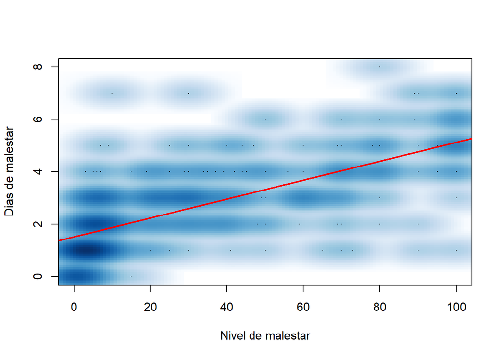

```r
smoothScatter(DFN$Nivel_de_malestar, DFN$Dias_de_malestar,  xlab = "Nivel de malestar", ylab = "Dias de malestar")
modelo1 <- lm(DFN$Dias_de_malestar ~ DFN$Nivel_de_malestar)
abline(modelo1, col = "red", lwd = 2)
```

*En esta gráfica se visualiza un relación linea positiva en aumento ya que la covarianza y correlación están creciendo juntas positivamente. Es así que los días de malestar están en proporción al nivel de malestar por recibir la tercera dosis.*

*En esta gráfica se visualiza un relación linea positiva en aumento ya que la covarianza y correlación están creciendo juntas positivamente. Es así que los días de malestar están en proporción al nivel de malestar por recibir la tercera dosis.*

*Mientras el nivel de malestar es muy alto, los días en los que pasas enfermo serán entre 2 a 7 días*

# Variables Aleatorias

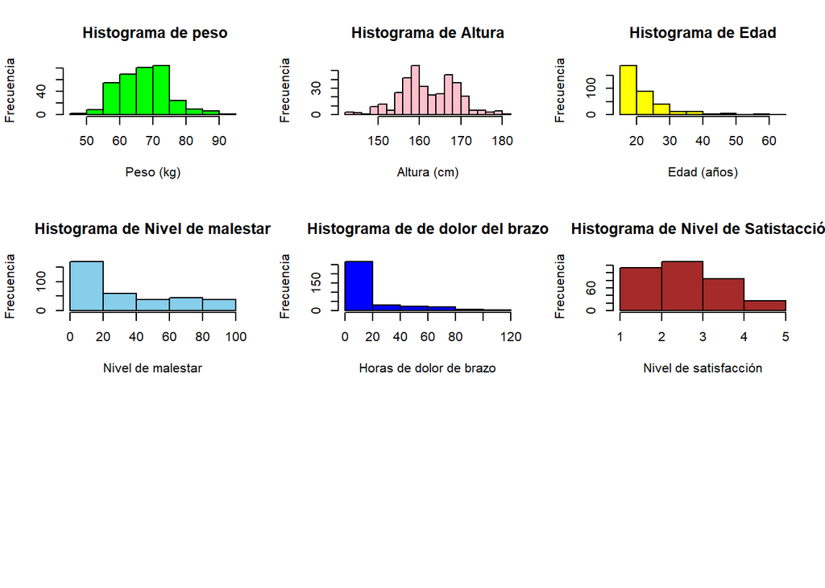

# Grafica con histograma y densidad

### **1.1. Continua: Modelo normal**

##### **Variable: Peso**

##### Criterios de análisis:

- Los valores de la media, la mediana y la moda deben coincidir.

```r
Descrip<-function(X){
  return(list('Media  '=round(mean(X,na.rm = TRUE ),2), 'Mediana   '=round(median(X, na.rm = TRUE),2), 'Moda    '=as.numeric(names(which(table(X)==max(table(X)))))))}
```

```r
mapply(Descrip, list('Peso  '=DFN$Peso))
```

```
##            Peso
## Media      67.71
## Mediana    67
## Moda       72
```

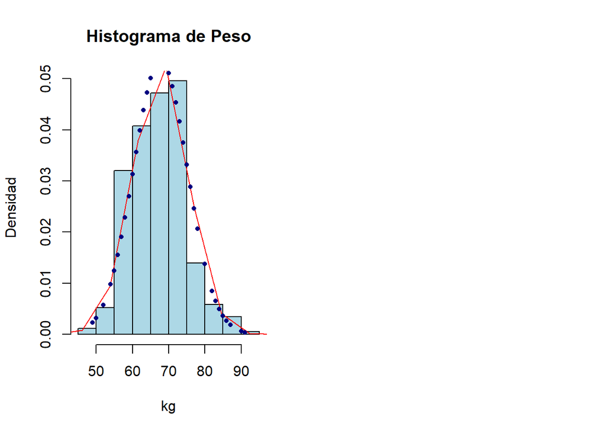

```r
op=par(mfrow=c(1,2))

#---------------------------

hist(DFN$Peso, breaks=10, freq = FALSE, main="Histograma de Peso",xlab="kg",ylab = "Densidad", col = "lightblue")
curve(dnorm(x, mean(DFN$Peso,na.rm = TRUE), sd = sd(DFN$Peso,na.rm = TRUE)), # Función dnorm a evaluar
      0, 300, 40, # Límites de x y nº de valores a evaluar
      col = "red",
      las = 1, # Etiquetas alineadas horizontalmente
      ann = FALSE, # Sin títulos en los ejes
      xaxp = c(0, 300, 10),  # Marcas del eje x
      ylim = c(0,0.03), # Límites del eje
      yaxs = "i", add = TRUE) # Estilo del eje y, ajustado a los límites
points(DFN$Peso, dnorm(DFN$Peso, mean(DFN$Peso,na.rm = TRUE), sd = sd(DFN$Peso,na.rm = TRUE)), ylab = "f(x)", pch = 20,  lwd = 0.1, col = "navyblue")
par(op)
```

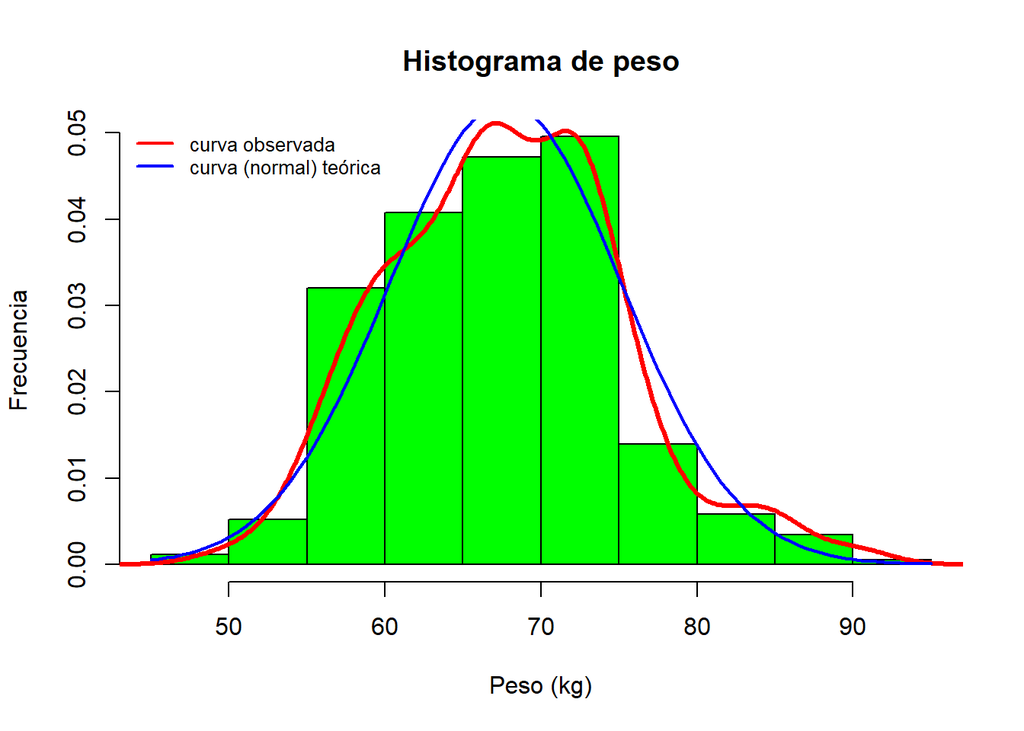

```r
hist(DFN$Peso,breaks=10, freq=FALSE, main="Histograma de peso", xlab="Peso (kg)",ylab = "Frecuencia", col="green")
lines(density(DFN$Peso, na.rm=TRUE),col="red",lwd=3)
curve(dnorm(x, mean(DFN$Peso,na.rm=TRUE), sd(DFN$Peso,na.rm=TRUE)), lwd = 2, col = "blue", add = T)
legend("topleft", c("curva observada", "curva (normal) teórica"),
       lty = 1, lwd = 2, col = c("red", "blue"), bty = "n",
       cex = 0.8)
```

```r
summary(DFN$Peso)
```

```
##    Min. 1st Qu.  Median    Mean 3rd Qu.    Max.    NA's
##   49.00   62.00   67.00   67.71   72.00   91.00      10
```

```r
round(sd(DFN$Peso , na.rm = TRUE),digits=2)               #DESVIACIÓN ESTANDAR
```

```
## [1] 7.45
```

```r
# El valor de la desviación estándar para esta variable es 7.45, entonces la variabilidad de las edades es moderado.

cv <-(sd(DFN$Peso, na.rm = TRUE)/mean(DFN$Peso, na.rm = TRUE))# Coeficiente de variación
round(cv,digits = 2)
```

```
## [1] 0.11
```

```r
# Su coeficiente de variación es 0.11, existe mayor homogeneidad en los datos y tenemos una muestra compacta,esto en consecuencia de los valores extremos.
```

**Observaciones de la variable Peso**

- Apreciamos que la mayoría de los datos están concentrados entre 57,63,67 y 72.
- Los valores de la media, moda y mediana son parecidos, por lo cual la variable se distribuye de manera casi simétrica.

### *1.2. Continua: Modelo exponencial*

##### *Variable: Horas de dolor en el brazo (Dolor_brazo)*

##### Criterios de análisis:

- Comparar el parámetro lambda con el valor máximo de la función de densidad

```
## Horas de dolor de brazo
##                   0.0617
```

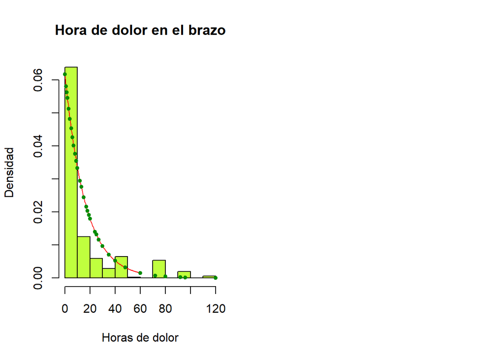

*Observaciones:* *Tratamos de aproximar el histograma de horas de dolor en el brazo a una distribución exponencial con lambda de 0.0617, sin embargo hay puntos en los que nuestro histograma pasa la distribución establecida*

*El máximo valor de la función de densidad en una variable aleatoria siempre es el valor lambda. En este caso concreto son muy similares, por lo que podemos decir que se asemeja a ese modelo*

*Al analizar el comportamiento exponencial de la variable hora de dolo en el brazo el cual es importante para nuestro estudio, pedimos confirmar dicha distribución, dado que al aumentar las horas de dolor en el brazo aumentará los días de malestar que pueda percibir la persona*

### *1.3. Discreta: Modelo Binomial*

##### *Variable: SEGURIDAD DE LA DOSIS*

##### Criterios de análisis

*Dónde:*

- Éxito -> Es seguro vacunarse
- Fracaso -> No es seguro vacunarse

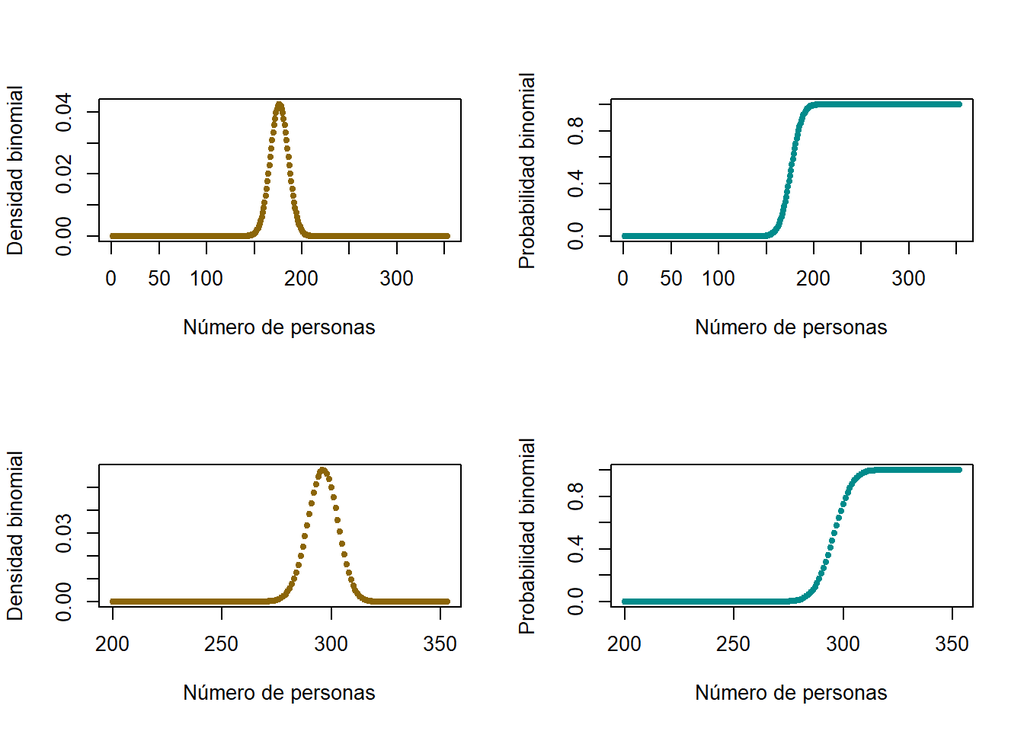

*Podemos observar que más personas optan por percibir que la dosis es segura para el retonar a la normalidad* *La mayoría de personas perciben que es mas segura ponerse la 3era dosis de la vacuna*